# Язык R и среда разработки RStudio

## Задание 1 Первый сеанс RStudio.

1. Запустите RStudio Cloud (https://rstudio.cloud). Пройдите регистрацию.
2. В своем рабочем пространстве создайте новый проект PracticeTask1.
3. Создайте простой набор данных (в терминологии R — вектор), состоящий из чисел 1, 2 и 4, и присвойте ему имя х. Выведите на экран фразу «Это мой первый сеанс работы с R».

```r
x <- c(1, 2, 4)
x
```

```
## [1] 1 2 4
```

```r
print("Это мой первый сеанс работы с R")
```

```
## [1] "Это мой первый сеанс работы с R"
```

4. Выполните команду, которая присваивает q значение (1,2,4,1,2,4,8), используя ранее определенный вектор x.

```r
q <- c(x, x, 8)
q
```

```
## [1] 1 2 4 1 2 4 8
```

5. Выведите на экран значение 3-го элемента вектора x.

```r
x[3]
```

```
## [1] 4
```

6. Выведите на экран элементы вектора x со 2 по 3

```r
x[2:3]
```

```
## [1] 2 4
```

7. Выведите на экран математическое ожидание и среднеквадратическое отклонение для элементов вектора x.

```r
mean(x)
```

```
## [1] 2.333333
```

```r
sd(x)
```

```
## [1] 1.527525
```

8. Выведите на экран перечень внутренних наборов данных, предназначенных для демонстраций.

```r
data()
```

9. Вычислите математическое ожидание и среднеквадратическое отклонение для набора данных Nile (этот набор содержит данные о течении Нила).

```r
mean(Nile)
```

```
## [1] 919.35
```

```r
sd(Nile)
```

```
## [1] 169.2275
```

10. Выведите гистограмму этих данных:

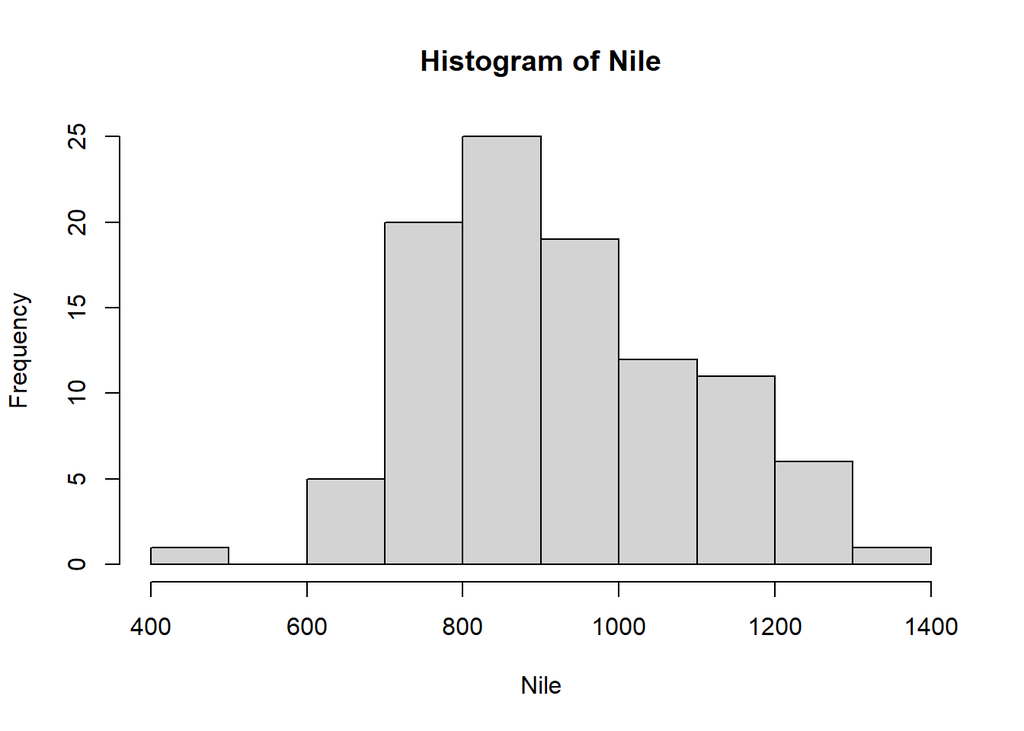

```r
hist(Nile)
```

11. Сохраните проект
12. Ответьте на вопросы:
1. Как сформировать вектор?  
   Вектор формируется с помощью функции c()
2. Что означает операция с (concatenate)?  
   Операция c (concatenate) объединяет элементы в один вектор
3. Как вывести на экран значение переменной величины?  
   Для вывода значения переменной используется функция print()
4. Нужно ли указывать тип переменной величины?  
   Нет, в R тип переменной определяется автоматически.
5. Как вывести на экран перечень демонстрационных наборов данных?  
   Для вывода перечня демонстрационных наборов данных используется функция data()
6. Как рассчитать среднеквадратическое отклонение?  
   Среднеквадратическое отклонение рассчитывается с помощью функции sd()
7. Как рассчитать математическое ожидание?  
   Математическое ожидание рассчитывается с помощью функции mean()
8. Как построить гистограмму?  
   Гистограмма строится с помощью функции hist()

## Задание 2 Работа с функциями в языке R.

1. Запустите RStudio Cloud. Создайте новый проект PracticeTask2 в своем рабочем пространстве.
2. Определите функцию с именем oddcount(), предназначенную для подсчета нечетных чисел в целочисленном векторе:

```r
# Функция подсчитывает количество нечетных целых чисел в x
oddcount <- function(x) {
  k <- 0 # в начале вычислений количество нечетных чисел равно 0
  for (n in x) {
    if (n %% 2 == 1) {# %% - вычисление остатка
      k <- k+1
    }
  }
  return(k)
}
```

3. Выполните команду Code – Source File…
4. В режиме интерпретатора вычислите количество нечетных чисел в сформированных в предыдущей работе наборов данных x и q с использованием созданной функции:

```r
print(oddcount(x))
```

```
## [1] 1
```

```r
print(oddcount(q))
```

```
## [1] 2
```

5. Попытайтесь вывести в интерпретаторе значения переменных k и n. Что Вы получили?

```
Error:
! объект 'k' не найден
```

6. Определите функцию sum_2, складывающую два числа, одно из которых имеет значение по умолчанию, равное 5 Протестируйте работу функции. Сохраните файл в своей папке под именем lab2_2.

```r
sum_2 <- function(a, b = 5)
{
  return(a + b)
}

print(sum_2(3))
```

```
## [1] 8
```

```r
print(sum_2(3, 8))
```

```
## [1] 11
```

7. Напишите функцию fx, определенную на всей числовой прямой Протестируйте работу функции.

```r
fx <- function(x) ifelse(x <= -2, 1-(x+2)^2, ifelse(x <= 2, -x/2, (x-2)^2 + 1))

print(fx(4.5))
```

```
## [1] 7.25
```

```r
print(fx(-4.5))
```

```
## [1] -5.25
```

```r
print(fx(1))
```

```
## [1] -0.5
```

8. Сохраните проект.
9. Ответьте на вопросы:
1. Как определить функцию?  
   Функция определяется с помощью ключевого слова function, например: my_function <- function(arg1, arg2) {}
2. Как описать тело функции?  
   Тело функции описывается в фигурных скобках {}, где размещается код, который будет выполняться.
3. Как записывается оператор if в языке R?  
   if записывается как: if (условие) { действия }
4. Как записывается оператор for в языке R?  
   for записывается как: for (i in 1:10) { действия }
5. Какие переменные являются глобальными?  
   Глобальными являются переменные, определенные вне функций и доступные во всем скрипте.
6. Какие переменные являются локальными по отношению к функции?  
   Локальными являются переменные, определенные внутри функции и доступные только в ее теле.
7. Как определить значения по умолчанию для аргументов функции?  
   Значения по умолчанию для аргументов функции определяются с помощью знака = в определении функции, например: function(arg1 = значение)
8. В каком порядке должны располагаться аргументы функции, не имеющие значений по умолчанию, и аргументы, имеющие значения по умолчанию?  
   Аргументы без значений по умолчанию должны располагаться перед аргументами с значениями по умолчанию.

## Задание 3. Структуры данных в R.

1. Запустите RStudio Cloud. В своем рабочем пространстве создайте новый проект PracticeTask3.
2. Создайте вектор а1 из вектора a1 получите вектор а1, добавив в середину вектора число 161.

```r
a <- c(34, 5, 73, 12)
a1 <- c(a[1:(length(a)/2)], 161, a[(length(a)/2):length(a)])
a1
```

```
## [1]  34   5 161   5  73  12
```

3. Создайте фактор month1, содержащий названия весенних месяцев года, при этом должен быть задан полный перечень месяцев и установлен порядок следования месяцев.

```r
month1 <- factor(c("Март", "Апрель", "Май"), levels = c("Март", "Апрель", "Май"), ordered = T)
month1
```

```
## [1] Март   Апрель Май
## Levels: Март < Апрель < Май
```

4. Сформируйте список emp, содержащий сведения о сотруднике: имя (name – имеет символьные значения); зарплата (salary – вещественное число), принадлежность к профсоюзу (union – логическое значение). Внесите данные об одном сотруднике: Irina, 40800.00, F. Выведите зарплату сотрудника. Измените зарплату сотрудника, задав значение 50000.00.

```r
emp <- list(name = "Irina",
            salary = 40800.00,
            union = F)
emp
```

```
## $name
## [1] "Irina"
##
## $salary
## [1] 40800
##
## $union
## [1] FALSE
```

5. Создайте фрейм department, описав сотрудников отдела атрибутами: name; salary; union. Введите данные по 2-м сотрудникам. Выведите имена всех сотрудников. Выведите зарплату второго сотрудника.

```r
department <- data.frame(name = "Sergey",
            salary = 42000,
            union = T)
department <- rbind(department, emp)

print(department)
```

```
##     name salary union
## 1 Sergey  42000  TRUE
## 2  Irina  40800 FALSE
```

```r
print(department$name)
```

```
## [1] "Sergey" "Irina"
```

```r
print(department[2, 2])
```

```
## [1] 40800
```

6. Создайте матрицу m размером 3х2.

```r
m <- matrix(1:6, 3, 2)
```

7. Сохраните проект.

## Задание 4. Управление данными в R.

1. Откройте файл PracticeTask3, созданный как результат выполнение предыдущего задания, сохраните объекты с именами subject1, department, month1 в файл mydata.RData.

```r
save(subject1, department, month1, file = "mydata.RData")
```

2. Создайте новый файл с именем lab2.R и загрузите в него объекты из файла mydata_lab1.RData, выведите объекты subject1, department, month1.

```r
rm(list = ls())
load("mydata.RData")
```

3. Сохраните текущий сеанс, воспользовавшись командой save.image().

```r
save.image()
```

4. Используя функцию rm() удалите объекты month1 и subject1, проверьте список оставшихся объектов, используя функцию ls(). Удалите все объекты. Используя файл .RData, восстановите объекты.

```r
rm(month1, subject1)
ls()
```

```
## [1] "department"
```

```r
rm(list = ls())
ls()
```

```
## character(0)
```

```r
load("mydata.RData")
```

5. Откройте файл R, созданный в ходе выполнения предыдущего задания. Запишите в файл pt_data.csv фрейм данных pt_data, определив параметр row.names=FALSE. Вернитесь в файл R текущей работы. Прочитайте содержимое файла pt_data.csv.

```r
pt_data <- read.csv("pt_data.csv", stringsAsFactors = F)

write.csv(pt_data, file = "pt_data.csv", row.names = F)
```

6. Загрузите файл usedcars.csv на сервер, если Вы используете среду RStudio Cloud, используя кнопку.
7. Загрузите данные их файла usedcars.csv во фрейм usedcars.

```r
usedcars <- read.csv("usedcars.csv")
```

8. Отобразите структуру usedcars, используя команду str().

```r
str(usedcars)
```

```
## 'data.frame':    150 obs. of  6 variables:
##  $ year        : int  2011 2011 2011 2011 2012 2010 2011 2010 2011 2010 ...
##  $ model       : chr  "SEL" "SEL" "SEL" "SEL" ...
##  $ price       : int  21992 20995 19995 17809 17500 17495 17000 16995 16995 16995 ...
##  $ mileage     : int  7413 10926 7351 11613 8367 25125 27393 21026 32655 36116 ...
##  $ color       : chr  "Yellow" "Gray" "Silver" "Gray" ...
##  $ transmission: chr  "AUTO" "AUTO" "AUTO" "AUTO" ...
```

9. Используя функцию summary() запросите статистику по всем числовым переменным usedcars.

```r
summary(usedcars)
```

```
##       year         model               price          mileage
##  Min.   :2000   Length:150         Min.   : 3800   Min.   :  4867
##  1st Qu.:2008   Class :character   1st Qu.:10995   1st Qu.: 27200
##  Median :2009   Mode  :character   Median :13592   Median : 36385
##  Mean   :2009                      Mean   :12962   Mean   : 44261
##  3rd Qu.:2010                      3rd Qu.:14904   3rd Qu.: 55125
##  Max.   :2012                      Max.   :21992   Max.   :151479
##     color           transmission
##  Length:150         Length:150
##  Class :character   Class :character
##  Mode  :character   Mode  :character
##
##
##
```

10. Используя функцию mean() посчитайте средние значения для всех числовых переменных usedcars.

```r
sapply(usedcars[, c(3, 4)], mean, rm.na = T)
```

```
##    price  mileage
## 12961.93 44260.65
```

11. Используя функцию median() посчитайте медианы для всех числовых переменных usedcars.

```r
sapply(usedcars[, c(3, 4)], median, rm.na = T)
```

```
##   price mileage
## 13591.5 36385.0
```

12. Изучите пятичисловую сводку для переменных price и mileage.

```r
summary(usedcars$price)
```

```
##    Min. 1st Qu.  Median    Mean 3rd Qu.    Max.
##    3800   10995   13592   12962   14904   21992
```

```r
summary(usedcars$mileage)
```

```
##    Min. 1st Qu.  Median    Mean 3rd Qu.    Max.
##    4867   27200   36385   44261   55125  151479
```

## Задание 5. Визуализация данных в R.